# Contrastes avanzados

Métodos de contraste de hipótesis y diseño de experimentos

Julio David Ruiz Mendoza

Mayo 2021

# Tarea 2

## Ejercicio 1

Lee el fichero dieta.csv en el que se recogen las siguientes variables y resuelve los apartados propuestos:

- id: Identificador del sujeto observado
- edad: grupo de edad al que pertenece el sujeto. Menores de 40, entre 40 y 50, y mayores de 50.
- tipoDiet: tipo de dieta que realiza.
- peso0: peso (kg) antes de comenzar la dieta.
- peso1: peso (kg) en la mitad de la dieta.
- peso2: peso (kg) al finalizar la dieta.

```r
dieta <- read.csv2("dieta.csv", dec = '.')
head(dieta)
```

```
##   id edad tipoDiet     peso0     peso1     peso2
## 1  1    3        1 122.01756 108.64895  90.94509
## 2  2    3        1 140.86780  89.24381  88.86856
## 3  3    2        3 110.52651 115.39116 100.41721
## 4  4    2        3 120.74844 106.17004 105.34358
## 5  5    1        1  82.73085  96.49512  91.90629
## 6  6    2        1 118.06524 104.84634  94.96339
```

1. Convierte en factor las variables edad y tipoDiet.

```r
dieta$edad <- as.factor(dieta$edad)
dieta$tipoDiet <- as.factor(dieta$tipoDiet)
str(dieta)
```

```
## 'data.frame':    24 obs. of  6 variables:
##  $ id      : int  1 2 3 4 5 6 7 8 9 10 ...
##  $ edad    : Factor w/ 3 levels "1","2","3": 3 3 2 2 1 2 3 1 2 1 ...
##  $ tipoDiet: Factor w/ 3 levels "1","2","3": 1 1 3 3 1 1 1 1 2 3 ...
##  $ peso0   : num  122 140.9 110.5 120.7 82.7 ...
##  $ peso1   : num  108.6 89.2 115.4 106.2 96.5 ...
##  $ peso2   : num  90.9 88.9 100.4 105.3 91.9 ...
```

2. Comprueba si hay diferencias en la media de los pesos antes de comenzar la dieta (Variable peso0) según el grupo de edad al que pertenece y encuentra en qué grupos están las diferencias.

Vamos a realizar un contraste de hipóetsis para ver si pueden tener las mismas medias. Podemos suponer que las muestras son independientes y debemos revisar el supuesto de normalidad y homocestidad. Finalmente realizar ANOVA de una vía.

```r
table( dieta$edad ) #n < 50
```

```
##
## 1 2 3
## 8 8 8
```

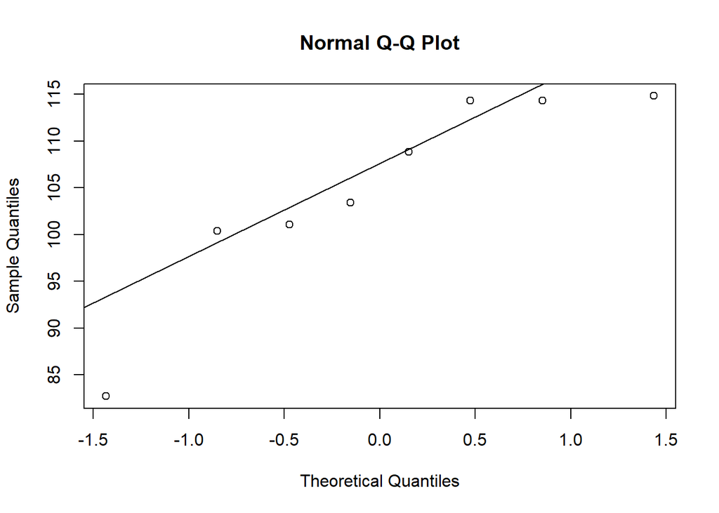

```
##
##  Shapiro-Wilk normality test
##
## data:  edad1
## W = 0.853, p-value = 0.1022
```

```r
edad1 <- dieta$peso0[dieta$edad == "1"]
edad2 <- dieta$peso0[dieta$edad == "2"]
edad3 <- dieta$peso0[dieta$edad == "3"]

qqnorm(edad1); qqline(edad1); shapiro.test(edad1)   #p-value = 0.1022
```

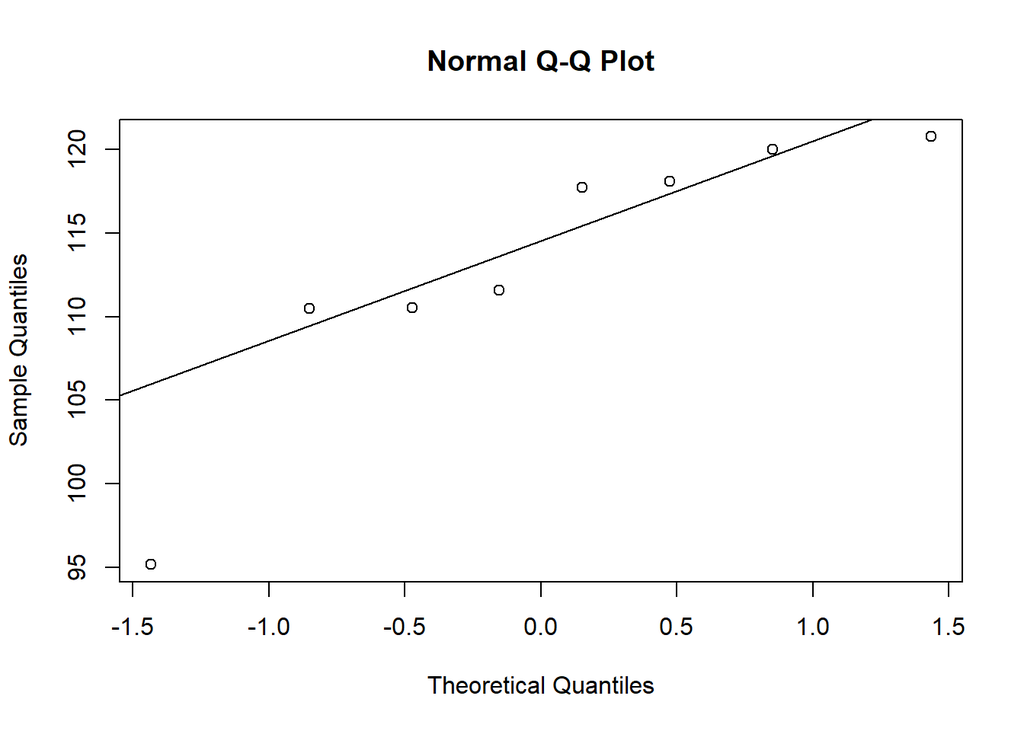

```
##
##  Shapiro-Wilk normality test
##
## data:  edad2
## W = 0.83071, p-value = 0.06038
```

```r
qqnorm(edad2); qqline(edad2); shapiro.test(edad2)   #p-value = 0.06038
```

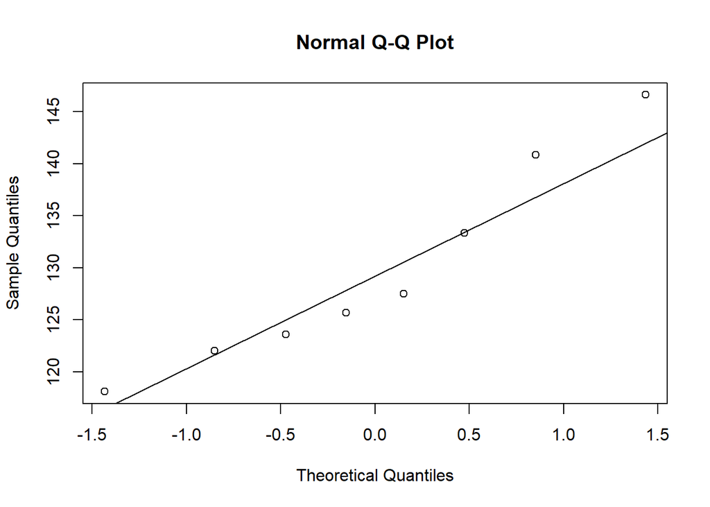

```
##
##  Shapiro-Wilk normality test
##
## data:  edad3
## W = 0.92652, p-value = 0.4849
```

```r
qqnorm(edad3); qqline(edad3); shapiro.test(edad3)   #p-value = 0.4849
```

```r
bartlett.test( dieta$peso0, dieta$edad )            #p-value = 0.8037
```

```
##
##  Bartlett test of homogeneity of variances
##
## data:  dieta$peso0 and dieta$edad
## Bartlett's K-squared = 0.43715, df = 2, p-value = 0.8037
```

```r
#Usamos este test porque tenemos mas de dos grupos.
```

Obtenemos p-valor mayor que 0.05 en todos los test realizados, por lo que los resultados nos llevan a suponer normalidad y homogeneidad de varianza. La hipótesis nula $H_0$ es que no hay diferencia entre las medias y la alternativa, $H_1$, que al menos una de las medias difiere del resto.

```r
modelo1b <- aov( peso0 ~ edad, data = dieta )
summary( modelo1b )
```

```
##             Df Sum Sq Mean Sq F value   Pr(>F)
## edad         2   2544  1272.0   13.46 0.000173 ***
## Residuals   21   1985    94.5
## ---
## Signif. codes:  0 '***' 0.001 '**' 0.01 '*' 0.05 '.' 0.1 ' ' 1
```

Con un p-value = 0.000173 < 0.05, rechazamos la hipótesis nula. Podemos aceptar la hipótesis alternativa de que al menos una de las medias es diferente. **La edad es relevante en el peso inicial**.

Veamos qué grupos de edad son los que difieren. Como solo tenemos 3 grupos (<6) usaremos el método de ajuste de Bonferroni.

```r
pairwise.t.test( dieta$peso0,
                 dieta$edad,
                 p.adj = "bonferroni")
```

```
##
##  Pairwise comparisons using t tests with pooled SD
##
## data:  dieta$peso0 and dieta$edad
##
##   1       2
## 2 0.33973 -
## 3 0.00015 0.00751
##
## P value adjustment method: bonferroni
```

**No se encuentra una diferencia significativa es para los grupos de edad 1 y 2** (p-value = 0.33973 > 0.05). **Para el resto de parejas** p-value es menor de 0.05 por lo que decimos que **hay diferencias apreciables**.

3. Comprueba si hay diferencias significativas en el peso final (peso2) según la interacción del grupo de edad al que pertenece el sujeto y el tipo de dieta al que se somete. Representa el gráfico de interacción con la edad en el eje x y el tipoDiet en tres líneas diferentes.

En este caso debemos realizar un **ANOVA de dos vías**. Se debe comprobar el supuesto de independencia, el supuesto de normalidad y el supuesto de homocedasticidad. Estos supuestos se deben comprobar para el factor edad y para el factor tipoDiet.

- Comprobación de supuestos para el factor edad:

```r
shapiro.test( dieta$peso2[dieta$edad == "1"] )    #p-value = 0.4284
```

```
##
##  Shapiro-Wilk normality test
##
## data:  dieta$peso2[dieta$edad == "1"]
## W = 0.91981, p-value = 0.4284
```

```r
shapiro.test( dieta$peso2[dieta$edad == "2"] )    #p-value = 0.9267
```

```
##
##  Shapiro-Wilk normality test
##
## data:  dieta$peso2[dieta$edad == "2"]
## W = 0.9739, p-value = 0.9267
```

```r
shapiro.test( dieta$peso2[dieta$edad == "3"] )    #p-value = 0.382
```

```
##
##  Shapiro-Wilk normality test
##
## data:  dieta$peso2[dieta$edad == "3"]
## W = 0.91386, p-value = 0.382
```

```r
bartlett.test( peso2 ~ edad, data = dieta )       #p-value = 0.1797
```

```
##
##  Bartlett test of homogeneity of variances
##
## data:  peso2 by edad
## Bartlett's K-squared = 3.4329, df = 2, p-value = 0.1797
```

Para todos los grupos de edad se obtiene un p-value mayor de 0.05 (0.4284, 0.9267, 0.382) y p-value = 0.1797 > 0.05, no podemos rechazar la hipótesis nula. Concluimos que nuestros datos cumplen el supuesto de normalidad y homogeneidad de varianzas.

- Comprobación de supuestos para el factor tipoDiet:

```r
shapiro.test( dieta$peso2[dieta$tipoDiet == "1"] )    #p-value = 0.3403
```

```
##
##  Shapiro-Wilk normality test
##
## data:  dieta$peso2[dieta$tipoDiet == "1"]
## W = 0.90802, p-value = 0.3403
```

```r
shapiro.test( dieta$peso2[dieta$tipoDiet == "2"] )    #p-value = 0.4113
```

```
##
##  Shapiro-Wilk normality test
##
## data:  dieta$peso2[dieta$tipoDiet == "2"]
## W = 0.91767, p-value = 0.4113
```

```r
shapiro.test( dieta$peso2[dieta$tipoDiet == "3"] )    #p-value = 0.8936
```

```
##
##  Shapiro-Wilk normality test
##
## data:  dieta$peso2[dieta$tipoDiet == "3"]
## W = 0.96944, p-value = 0.8936
```

```r
bartlett.test( peso2 ~ tipoDiet, data = dieta )       #p-value = 0.4568
```

```
##
##  Bartlett test of homogeneity of variances
##
## data:  peso2 by tipoDiet
## Bartlett's K-squared = 1.5668, df = 2, p-value = 0.4568
```

Para todos los tipos de de dieta se obtiene un p-value mayor de 0.05 (0.3403, 0.4113, 0.8936) y p-value = 0.4568 > de 0.05, no podemos rechazar la hipótesis nula. Por lo tanto, podemos concluir que nuestros datos cumplen el supuesto de normalidad y homogeneidad de varianzas.

- Estimación del modelo ANOVA

```r
table( dieta$edad )
```

```
##
## 1 2 3
## 8 8 8
```

```r
table( dieta$tipoDiet )
```

```
##
## 1 2 3
## 8 8 8
```

Los datos están balanceados.

Realizamos la estimación del modelo ANOVA de dos vías:

```r
modelo1c <- aov( peso2 ~ edad * tipoDiet, data = dieta )

summary( modelo1c )
```

```
##               Df Sum Sq Mean Sq F value   Pr(>F)
## edad           2   84.2    42.1   1.320    0.296
## tipoDiet       2 1391.1   695.5  21.823 3.62e-05 ***
## edad:tipoDiet  4  160.0    40.0   1.255    0.331
## Residuals     15  478.1    31.9
## ---
## Signif. codes:  0 '***' 0.001 '**' 0.01 '*' 0.05 '.' 0.1 ' ' 1
```

La variable tipoDiet tiene un efecto significativo (3.62e-05 < 0.05), la edad no (0.296 > 0.05) y no hay interacción entre ambas (0.331 > 0.05), esto es, se acepta la hipótesis nula. No hay diferencias significativas en el peso final según el grupo de edad y el tipo de dieta.

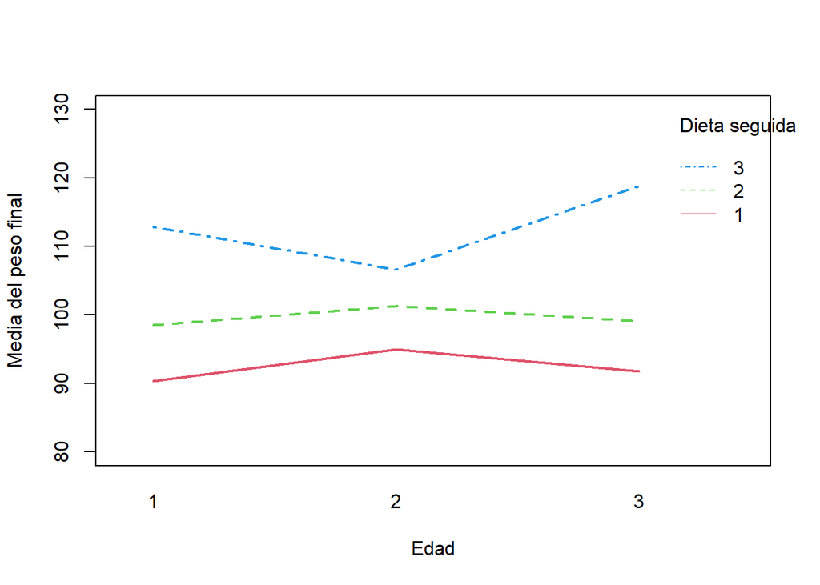

```r
interaction.plot( dieta$edad, dieta$tipoDiet, dieta$peso2, ylim = c( 80, 130 ),
                  col = c( 2, 3, 4 ), lty = c( 1,2,4 ), lwd = 2,
                  ylab = "Media del peso final", xlab = "Edad", trace.label = "Dieta seguida" )
```

4. Comprueba si la media de los pesos difieren dependiendo del momento de la dieta en el que se esté. Reestructura el data frame con la función `melt()` del paquete `reshape2`. En caso de que difieran, encuentra en qué grupos están las diferencias.

En este caso tenemos **ANOVA para medidas repetidas** y necesitamos comprobar el supuesto de esfericidad.

Vamos a reestructurar los datos

```r
library( reshape2 )
dietaRe <- melt( dieta, id = c( "id", "edad", "tipoDiet" ),
measure = c( "peso0", "peso1", "peso2" ),
variable.name = "Periodo",
value.name = "Peso" )
head( dietaRe )
```

```
##   id edad tipoDiet Periodo      Peso
## 1  1    3        1   peso0 122.01756
## 2  2    3        1   peso0 140.86780
## 3  3    2        3   peso0 110.52651
## 4  4    2        3   peso0 120.74844
## 5  5    1        1   peso0  82.73085
## 6  6    2        1   peso0 118.06524
```

La función `ezANOVA()` del paquete `ez` además del modelo ANOVA lleva a cabo el análisis de supuestos previo:

```r
summary( aov( Peso ~ Periodo + Error( id / Periodo ), data = dietaRe ) )
```

```
##
## Error: id
##           Df Sum Sq Mean Sq F value Pr(>F)
## Residuals  1  163.6   163.6
##
## Error: id:Periodo
##         Df Sum Sq Mean Sq
## Periodo  2   1495   747.6
##
## Error: Within
##           Df Sum Sq Mean Sq F value  Pr(>F)
## Periodo    2   1636   818.1   5.479 0.00629 **
## Residuals 66   9855   149.3
## ---
## Signif. codes:  0 '***' 0.001 '**' 0.01 '*' 0.05 '.' 0.1 ' ' 1
```

```r
library( ez )
options( contrasts = c( "contr.sum", "contr.poly" ) )
ezANOVA( data = dietaRe, dv = Peso, wid = id, within = Periodo, type = 3 )
```

```
## $ANOVA
##    Effect DFn DFd        F            p p<.05       ges
## 2 Periodo   2  46 9.007468 0.0004999883     * 0.2143998
##
## $`Mauchly's Test for Sphericity`
##    Effect         W         p p<.05
## 2 Periodo 0.9348576 0.4766505
##
## $`Sphericity Corrections`
##    Effect       GGe        p[GG] p[GG]<.05      HFe        p[HF] p[HF]<.05
## 2 Periodo 0.9388416 0.0006806327         * 1.019405 0.0004999883         *
```

Obtenemos un p-valor = 0.0004999883 < 0.05 por lo que aceptamos que hay diferencias de pesos al comenzar la dieta, en mitad y al finalizar.

```r
friedman.test( Peso ~ Periodo | id , data = dietaRe )
```

```
##
##  Friedman rank sum test
##
## data:  Peso and Periodo and id
## Friedman chi-squared = 12, df = 2, p-value = 0.002479
```

```r
pairwise.wilcox.test( dietaRe$Peso, dietaRe$Periodo, p.adjust = "bonferroni", exact = FALSE, paired = TRUE )
```

```
##
##  Pairwise comparisons using Wilcoxon signed rank test with continuity correction
##
## data:  dietaRe$Peso and dietaRe$Periodo
##
##       peso0  peso1
## peso1 0.1412 -
## peso2 0.0011 0.2224
##
## P value adjustment method: bonferroni
```

Los datos que difieren son en el inicio y final de la dieta.

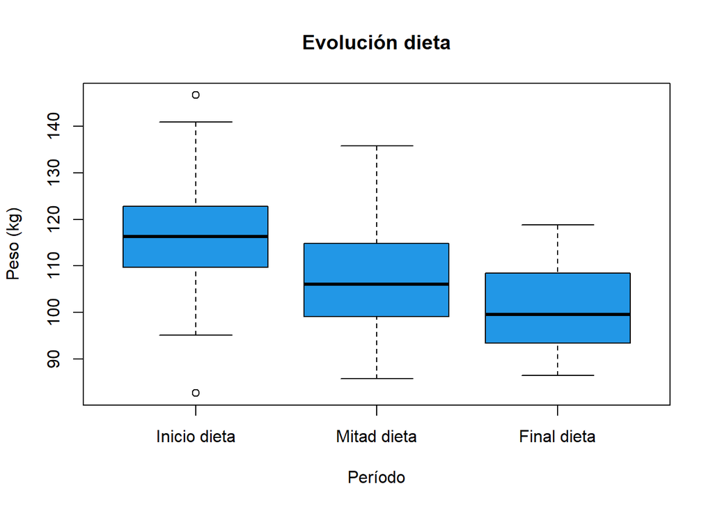

```r
boxplot( dietaRe$Peso ~ dietaRe$Periodo,  varwidth = TRUE, ylab = "Peso (kg)", main="Evolución dieta",
         xlab = "Período", names = c("Inicio dieta", "Mitad dieta", "Final dieta"), col = 28 )
```

## Ejercicio 2

Una empresa quiere saber si existe relación entre el salario de un trabajador y las ausencias del mismo al trabajo. Para el estudio se dividió el salario en distintas categorías y se eligió aleatoriamente un grupo de trabajadores para determinar el número de días que habían faltado en los últimos tres años. Los datos están en la base william.csv. ¿Se puede construir un modelo que relacione la categoría del salario y las ausencias en el trabajo?

```r
william <- read.csv2("william.csv")
str(william)
```

```
## 'data.frame':    15 obs. of  2 variables:
##  $ salario  : int  11 10 8 5 9 7 3 11 8 7 ...
##  $ ausencias: int  18 17 29 36 11 28 35 14 20 32 ...
```

1. Realiza el ajuste del modelo con la variable explicativa salario. Explica los resultados obtenidos y haz la gráfica de los datos con la recta de regresión.

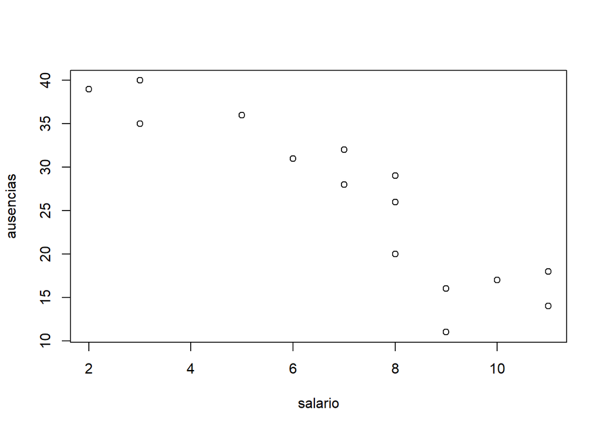

```r
plot(william)
```

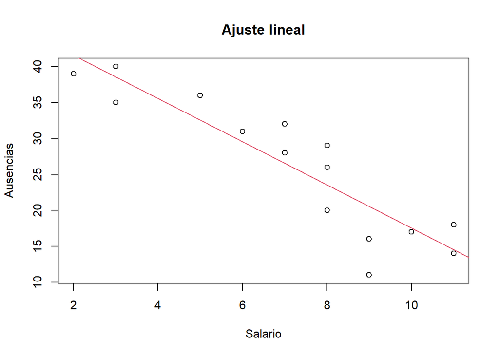

```r
modelo2a <- lm(william$ausencias~william$salario)

plot(william, xlab = "Salario", ylab = "Ausencias", main="Ajuste lineal" )
abline(modelo2a, col=2)
```

```r
summary(modelo2a)
```

```
##
## Call:
## lm(formula = william$ausencias ~ william$salario)
##
## Residuals:
##    Min     1Q Median     3Q    Max
## -9.516 -3.053  1.428  2.961  5.475
##
## Coefficients:
##                 Estimate Std. Error t value Pr(>|t|)
## (Intercept)      47.6002     3.0789  15.460 9.50e-10 ***
## william$salario  -3.0094     0.4027  -7.474 4.67e-06 ***
## ---
## Signif. codes:  0 '***' 0.001 '**' 0.01 '*' 0.05 '.' 0.1 ' ' 1
##
## Residual standard error: 4.294 on 13 degrees of freedom
## Multiple R-squared:  0.8112, Adjusted R-squared:  0.7967
## F-statistic: 55.86 on 1 and 13 DF,  p-value: 4.672e-06
```

Tenemos un $R^2$ = 0.7967, este valor indica una buena capacidad de predicción por parte de la variable predictora.

El modelo ajustado es $ausencias = 47.60 − 3.01 \cdot salario$

2. Realiza el diagnóstico del modelo: Normalidad de los residuos, homogeneidad de varianzas e incorrelación de los residuos.

```r
william$fitted.modelo <- fitted( modelo2a )       #valores ajustados
william$residuals.modelo <- residuals( modelo2a ) #residuos
william$rstudent.modelo <- rstudent( modelo2a )   #estadisticos

shapiro.test( william$rstudent.modelo )
```

```
##
##  Shapiro-Wilk normality test
##
## data:  william$rstudent.modelo
## W = 0.91538, p-value = 0.1637
```

p-value = 0.1637 > 0.05, no podemos rechazar la hipótesis nula, suponemos normalidad de residuos.

```r
library(lmtest)
bptest( modelo2a )
```

```
##
##  studentized Breusch-Pagan test
##
## data:  modelo2a
## BP = 0.52916, df = 1, p-value = 0.467
```

p-value = 0.467 > 0.05, no podemos rechazar la hipótesis nula y suponemos homogeneidad de varianzas.

```r
dwtest( ausencias ~ salario,  alternative = "two.sided",  data = william)
```

```
##
##  Durbin-Watson test
##
## data:  ausencias ~ salario
## DW = 2.452, p-value = 0.3763
## alternative hypothesis: true autocorrelation is not 0
```

p-value = 0.3763 > 0.05, no podemos rechazar la hipótesis nula. Suponemos incorrelación de los residuos.